[figure not shown]

CO(w/o STI)-2

General Description

COOLING

1. General Description

A: SPECIFICATION

Cooling system

Electric fan + Forced engine coolant

circulation system

Total engine

coolant

capacity

L (US qt, Imp qt)

CVT model: Approx. 8.4 (8.9, 7.4)

MT model: Approx. 8.2 (8.7, 7.2)

Water pump

Type Centrifugal impeller type

Discharge performance

Discharge rate L (US gal, Imp gal)/min 248 (65.5, 54.6)

Pump speed — Discharge pressure 8,580 rpm — 88 kPa (9.2 mAq)

Engine coolant temperature 80°C (176°F)

Impeller diameter mm (in) 56 (2.2)

Number of impeller vanes 7

Pump pulley diameter mm (in) 100 (3.9)

Thermostat

Type Wax pellet type

Starting temperature to open 86 — 90°C (187 — 194°F)

Fully opens 95°C (203°F)

Valve lift mm (in) 8.0 (0.315) or more

Valve opening size mm (in) 32 (1.26)

Radiator fan

Motor input

Main fan W 120

Sub fan W 120

Fan diameter / Blade

Main fan 318.5 mm (12.54 in)/9

Sub fan 318.5 mm (12.54 in)/11

Radiator

Type Down flow, pressure type

Core dimensions Width × Height × Thickness mm (in)

687.4 × 340 × 27

(27.06 × 13.39 × 1.06)

Pressure range in which

cap valve is open

Positive

pressure

side

Standard 93 — 123 (0.95 — 1.25, 14 — 18)

Limit 83 (0.85, 12)

Negative

pressure

side

Standard

–1.0 to –4.9 or less

(–0.01 — –0.05, –0.1 — –0.7)

Fins Corrugated fin type

Reservoir

tank

Capacity L (US qt, Imp qt) 0.45 (0.48, 0.40)

Recommended materials Item number Alternative

Coolant

SUBARU SUPER COOLANT

(concentrated type)

—

—

SUBARU SUPER COOLANT

(diluted type)

K0670Y0001

Water for dilution Distilled water — Soft water or tap water

Cooling system protective

agent

Cooling system conditioner SOA345001 —

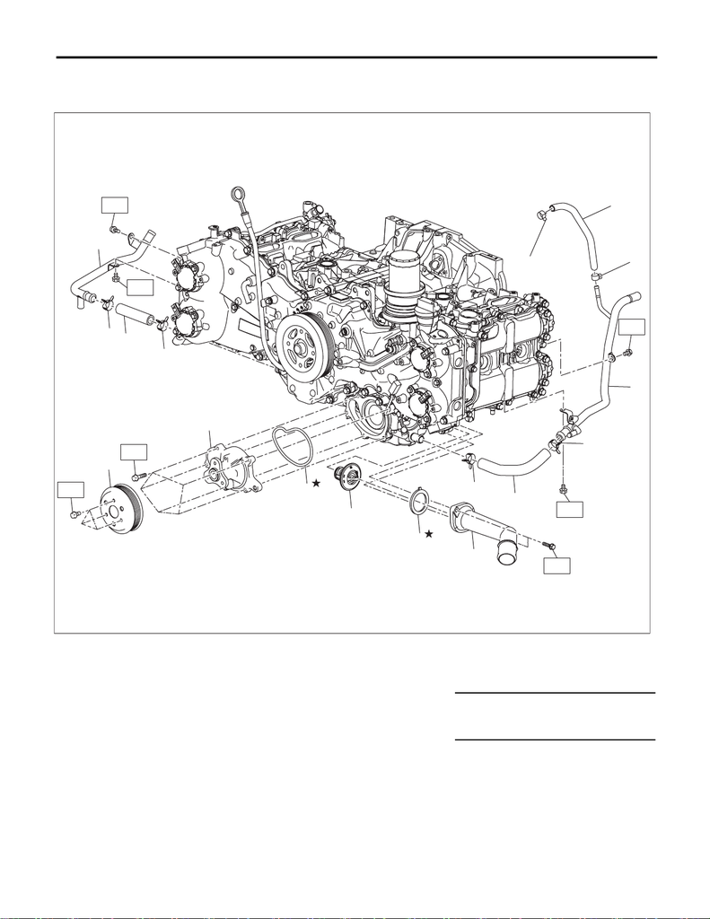

CO(w/o STI)-3

General Description

COOLING

B: COMPONENT

1. WATER PUMP

(1) Water pump pulley (7) Clip (13) Clip

(2) Water pump ASSY (8) Water pipe hose LH (14) Water pipe hose RH

(3) Gasket (9) Water pipe LH

(4) Thermostat (10) Preheater hose Tightening torque: N·m (kgf-m, ft-lb)

(5) Gasket (11) Clip T1: 6.4 (0.7, 4.7)

(6) Thermostat cover (12) Water pipe RH T2: 14 (1.4, 10.3)

(12)

(1)

(2)

(13)

(13)

(4)

(3)

(6)

(5)

(14)

T1

T1

T2

T1

T1

T1

(10)

(11)

(11)

T1

(9)

(7)

(8)

(7)

CO-03228

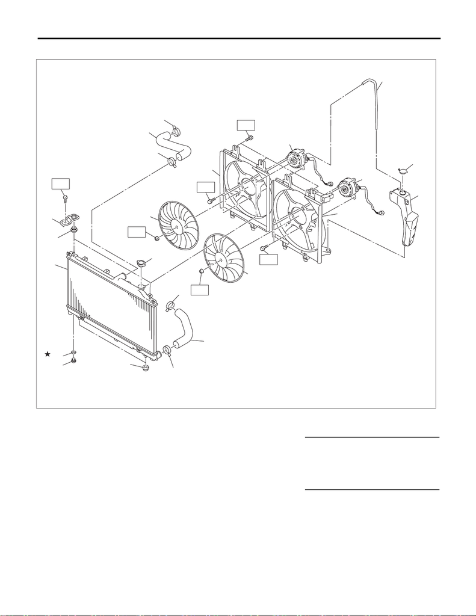

CO(w/o STI)-4

General Description

COOLING

2. RADIATOR & RADIATOR FAN

(1) Radiator lower cushion (10) Radiator sub fan shroud (19) Radiator cap

(2) Radiator (11) Radiator main fan shroud

(3) Radiator upper cushion (12) Radiator main fan Tightening torque: N·m (kgf-m, ft-lb)

(4) Radiator upper bracket (13) Radiator sub fan T1: 3.4 (0.3, 2.5)

(5) Clip (14) Main fan motor T2: 4.41 (0.45, 3.25)

(6) Radiator inlet hose (15) Sub fan motor T3: 7.5 (0.8, 5.5)

(7) Engine coolant reservoir tank cap (16) Radiator outlet hose T4: 12 (1.2, 8.9)

(8) Over flow hose (17) Radiator drain plug

(9) Engine coolant reservoir tank (18) O-ring

(12)

T1

(15)

(14)

(11)

(10)

T2

T2

(13)

T1

CO-03365

(9)

(7)

(8)

(5)

(6)

(5)

T3

(1)

(2)

(3)

(17)

(18)

(16)

(5)

(5)

(19)

(3)

(4)

T4

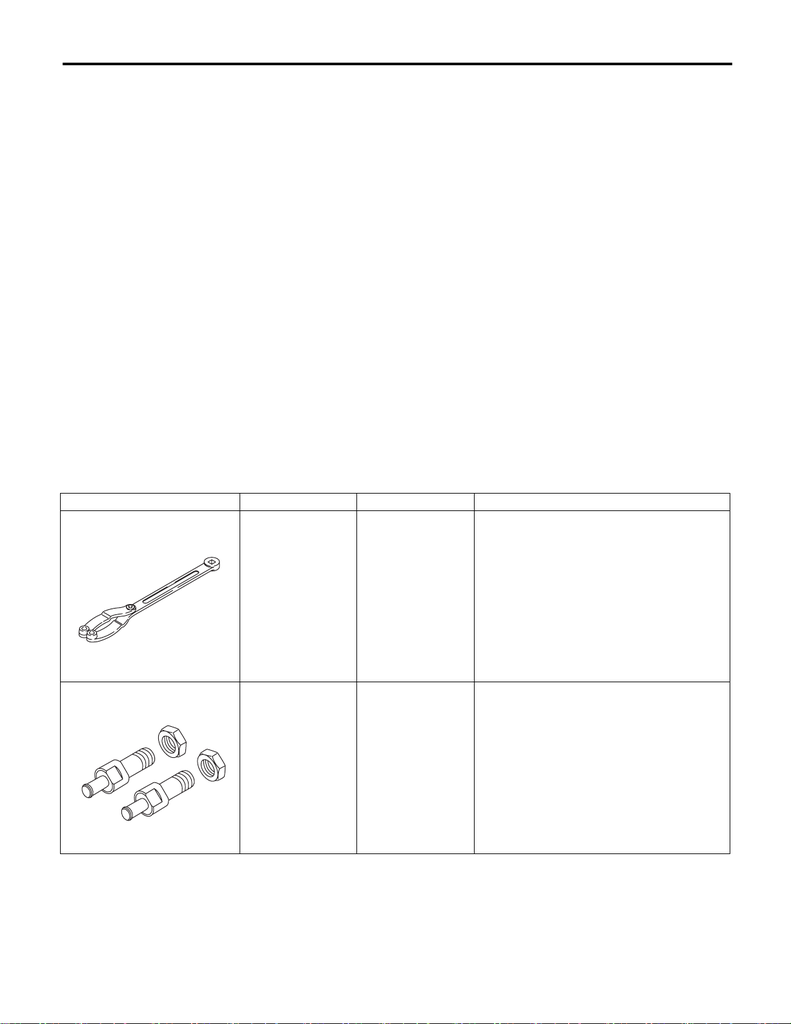

CO(w/o STI)-5

General Description

COOLING

C: CAUTION

• Prior to starting work, pay special attention to the following:

1. Always wear work clothes, a work cap, and protective shoes. Additionally, wear a helmet, protective

goggles, etc. if necessary.

2. Protect the vehicle using a seat cover, fender cover, etc.

3. Prepare the service tools, clean cloth, containers to catch grease and oil, etc.

• Prepare a container and cloth to prevent scattering of engine coolant when performing work where engine

coolant can be spilled. If the oil spills, wipe it off immediately to prevent from penetrating into floor or flowing

out for environmental protection.

• Vehicle components are extremely hot immediately after driving. Be wary of receiving burns from heated

parts.

• When performing a repair, identify the cause of trouble and avoid unnecessary removal, disassembly and

replacement.

• Before disconnecting connectors of sensors or units, be sure to disconnect the ground cable from battery.

• Always use the jack-up point when the shop jacks or rigid racks are used to support the vehicle.

• Remove contamination including dirt and corrosion before removal, installation, disassembly or assembly.

• Keep the removed parts in order and protect them from dust and dirt.

• All removed parts, if to be reused, should be reinstalled in the original positions with attention to the correct

directions, etc.

• Bolts, nuts and washers should be replaced with new parts as required.

• Be sure to tighten the fasteners including bolts and nuts to the specified torque.

• Follow all government and local regulations concerning disposal of refuse when disposing engine coolant.

D: PREPARATION TOOL

1. SPECIAL TOOL

ILLUSTRATION TOOL NUMBER DESCRIPTION REMARKS

18355AA000 PULLEY WRENCH Used for removing and installing water pump

pulley.

18334AA030 PULLEY WRENCH

PIN SET

Used for removing and installing water pump

pulley.

ST18355AA000

ST18334AA030

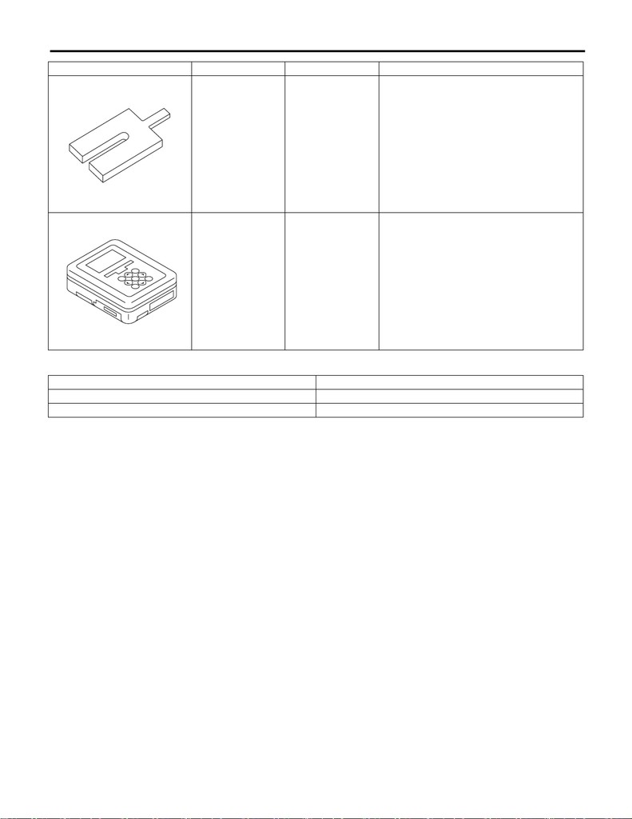

CO(w/o STI)-6

General Description

COOLING

2. GENERAL TOOL

18632AA030

(Newly adopted tool)

STAND ASSY Used for removing and installing the water pipe

assembly LH.

1B022XU0 SUBARU SELECT

MONITOR III KIT

Used for troubleshooting the electrical system.

TOOL NAME REMARKS

Circuit tester Used for measuring resistance and voltage.

Radiator cap tester Used for checking radiator and radiator cap.

ILLUSTRATION TOOL NUMBER DESCRIPTION REMARKS

ST18632AA030

ST1B022XU0